# Statistical Inference Course Project

nthehai01

2/23/2022

## Overview

The project consists of two parts:

1. A simulation exercise
2. Basic inferential data analysis

## Part 1: Simulation Exercise

#### Simulations

In this project, I will investigate the exponential distribution of averages of 40 exponentials with $\lambda$ = 0.2 and compare it with the Central Limit Theorem.

```r
## initialize
n = 40
lambda = 0.2
```

Creating a thousand exponential distribution simulations:

```r
n.sim = 1000

set.seed(42)
sim <- replicate(n.sim, rexp(n, lambda))
```

Calculating mean of the each simulation:

```r
mean.sim <- apply(sim, 2, mean)
```

#### Sample Mean versus Theoretical Mean

**Note:** the theoretical mean and standard deviation of exponential distribution are the same with
$$\frac{1}{\lambda}$$
.

The sample mean:

```r
mean.sam <- mean(mean.sim)
mean.sam
```

```
## [1] 4.986508
```

The theoretical mean:

```r
mean.theo <- 1 / lambda
mean.theo
```

```
## [1] 5
```

As can be seen from the results, the sample mean and the theoretical mean are pretty much close.

#### Sample Variance versus Theoretical Variance

The sample variance:

```r
var.sam <- var(mean.sim)
var.sam
```

```
## [1] 0.6344405
```

The theoretical variance:

```r
var.theo <- (1/lambda)^2 / n
var.theo
```

```
## [1] 0.625
```

As can be seen from the results, the sample variance and the theoretical variance are pretty much close.

#### Distribution

In this session, I will plot the simulations and two distribution curves, one for the simulations and one for the theoretical distribution.

```r
mean.df <- data.frame(mean = mean.sim)
```

Creating a histogram for the simulations:

```r
library(ggplot2)
hist.sim <- ggplot(mean.df, aes(x = mean)) +
  geom_histogram(aes(y =..density..),
                 binwidth = lambda,
                 fill="lightcoral",
                 color="black") +
  ggtitle("Exponential distribution")
```

Adding a normal curve for the simulations:

```r
hist.sim <- hist.sim + stat_function(fun = dnorm,
                                     args = list(mean = mean.sam,
                                                 sd = sqrt(var.sam)),
                                     aes(colour = "Simulations"),
                                     size = 1.5)
```

Adding a normal curve for the theoritial distribution:

```r
hist.sim <- hist.sim + stat_function(fun = dnorm,
                                     args = list(mean = mean.theo,
                                                 sd = sqrt(var.theo)),
                                     aes(colour = "Theory"),
                                     alpha = 0.6,
                                     size = 1.5)
```

Adding color to two distribution curves:

```r
hist.sim <- hist.sim + scale_colour_manual("Type", values=c("yellow", "black"))
```

Plotting:

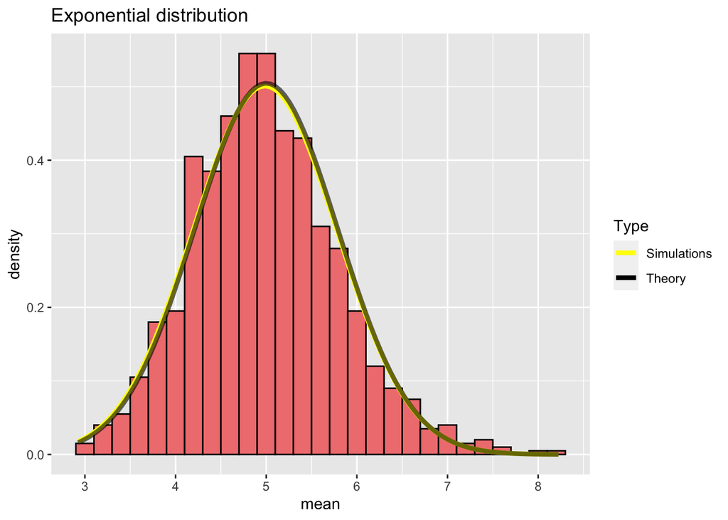

```r
hist.sim
```

## Part 2: Basic Inferential Data Analysis

In the second portion of the project, I am going to analyze the ToothGrowth data in the R datasets package.

#### Loading the ToothGrowth data

```r
data(ToothGrowth)
```

#### Performing some basic exploratory data analyses

The response is the *length* of odontoblasts (cells responsible for tooth growth) in 60 guinea pigs. Each animal received one of three *dose* levels of vitamin C (0.5, 1, and 2 mg/day) by one of two delivery *methods*, orange juice (coded as OJ) or ascorbic acid (a form of vitamin C and coded as VC).

```r
str(ToothGrowth)
```

```
## 'data.frame':    60 obs. of  3 variables:
##  $ len : num  4.2 11.5 7.3 5.8 6.4 10 11.2 11.2 5.2 7 ...
##  $ supp: Factor w/ 2 levels "OJ","VC": 2 2 2 2 2 2 2 2 2 2 ...
##  $ dose: num  0.5 0.5 0.5 0.5 0.5 0.5 0.5 0.5 0.5 0.5 ...
```

It shows that our data set containing 60 observations and 3 variables with `len` and `dose` are numerical, `supp` is a 2-level factor.

Check for missing values:

```r
apply(is.na(ToothGrowth), 2, sum)
```

```
##  len supp dose
##    0    0    0
```

Let’s look at how many samples we have for each type of doe and method pairs:

```r
table(ToothGrowth$supp, ToothGrowth$dose)
```

```
##
##      0.5  1  2
##   OJ  10 10 10
##   VC  10 10 10
```

We see that there are 10 samples for each pair of dose and method, 20 samples for each dose and 30 samples for each method.

Let’s look at a box plot of tooth length broken down by method and dose:

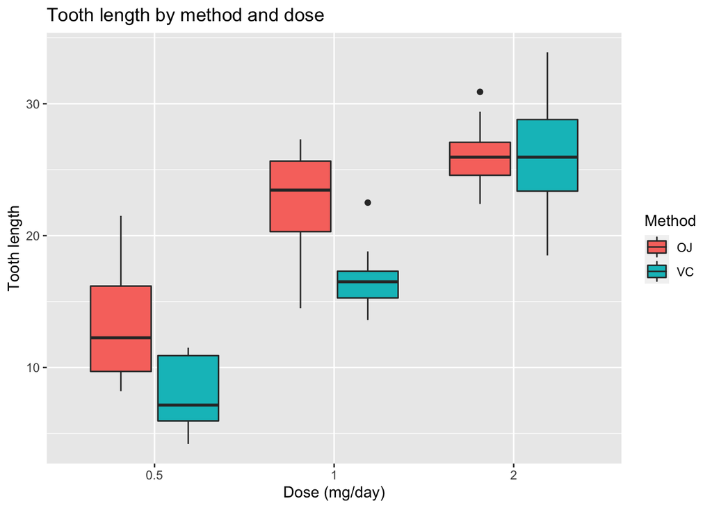

```r
library(ggplot2)
ggplot(ToothGrowth, aes(x = factor(dose), y = len, fill = supp)) +
  geom_boxplot() +
  ggtitle("Tooth length by method and dose") +
  xlab("Dose (mg/day)") +
  ylab("Tooth length") +
  guides(fill=guide_legend(title='Method'))
```

From the plot, we see:

1. For 2.0 mg/day dose, there is no difference in tooth length between OJ and VC.
2. For 0.5 mg/day and 1.0 mg/day dose, the lengths of odontoblasts with OJ method are higher than with VC method.
3. For OJ and VC, a dose of 1.0 mg/day is always higher than a dose of 0.5 mg/day when it comes to tooth length.

#### Providing a basic summary of the data

```r
summary(ToothGrowth)
```

```
##       len        supp         dose
##  Min.   : 4.20   OJ:30   Min.   :0.500
##  1st Qu.:13.07   VC:30   1st Qu.:0.500
##  Median :19.25           Median :1.000
##  Mean   :18.81           Mean   :1.167
##  3rd Qu.:25.27           3rd Qu.:2.000
##  Max.   :33.90           Max.   :2.000
```

#### Using confidence intervals and/or hypothesis tests to compare tooth growth by supp and dose

**First hypothesis:** *$H_0$:* Both types of supplement are involving in tooth length.

```r
t.test(len ~ supp, data = ToothGrowth, alternative = "two.sided")
```

```
##
##  Welch Two Sample t-test
##
## data:  len by supp
## t = 1.9153, df = 55.309, p-value = 0.06063
## alternative hypothesis: true difference in means between group OJ and group VC is not equal to 0
## 95 percent confidence interval:
##  -0.1710156  7.5710156
## sample estimates:
## mean in group OJ mean in group VC
##         20.66333         16.96333
```

Since the p-value > $\alpha$ = 0.05, we can not reject the null hypothesis. Both supplements are delivering same tooth growth.

**Second hypothesis:** *$H_0$:* For 0.5 mg/day and 1.0 mg/day dose, the lengths of odontoblasts with OJ method are less than or equal to VC method.

```r
## filter the record with 0.5 or 1.0 dose
filtered.dose <- ToothGrowth[ToothGrowth$dose != 2.0, ]

t.test(len ~ supp, data = filtered.dose, alternative = "greater")
```

```
##
##  Welch Two Sample t-test
##
## data:  len by supp
## t = 3.0503, df = 36.553, p-value = 0.002119
## alternative hypothesis: true difference in means between group OJ and group VC is greater than 0
## 95 percent confidence interval:
##  2.497234      Inf
## sample estimates:
## mean in group OJ mean in group VC
##           17.965           12.375
```

**Third hypothesis:** *$H_0$:* For OJ and VC, a dose of 0.5 mg/day is always higher than or equal to a dose of 1.0 mg/day when it comes to tooth length.

```r
t.test(len ~ dose, data = filtered.dose, alternative = "less")
```

```
##
##  Welch Two Sample t-test
##
## data:  len by dose
## t = -6.4766, df = 37.986, p-value = 6.342e-08
## alternative hypothesis: true difference in means between group 0.5 and group 1 is less than 0
## 95 percent confidence interval:
##       -Inf -6.753323
## sample estimates:
## mean in group 0.5   mean in group 1
##            10.605            19.735
```

Since the p-value < $\alpha$ = 0.05, we reject the null hypothesis. For OJ and VC supplements, a dose of 1.0 mg/day is always higher than a 0.5 mg/day dose in term of tooth length.

#### Conclusion

According to the t-tests applied in the previous section and according to the summarised data, it is clear that:

- The OJ and VC supplements are delivering same tooth growth but for 0.5 mg/day and 1.0 mg/day dose, the lengths of odontoblasts with OJ method are greater than VC method.
- For OJ and VC supplements, a dose of 1.0 mg/day is always higher than a 0.5 mg/day dose in term of tooth length.